# Data Visualization 2 Final project

Akos Almasi

2023-01-31

## Introduction

In the Data Visualization project, I used the data available on Formula 1 to illustrate the trends and to find answers to how these trends make the sport consumable and likeable for people who do not have a deeper knowledge of cars. To implement the project, I used the R programming language and the Formula 1 data available on tidytuesday, which contains the most relevant information from 1950 to the middle of the 2021 season. The project was not intended to be a comprehensive guide to the sport, so I did not focus on readily available knowledge (e.g. rules), but looked for correlations in the data.

```r
# Data sources
circuits <- fread('https://raw.githubusercontent.com/rfordatascience/tidytuesday/master/data/2021/2021-09-07/circuits.csv')
constructor_results <- fread('https://raw.githubusercontent.com/rfordatascience/tidytuesday/master/data/2021/2021-09-07/constructor_results.csv')
constructor_standings <- fread('https://raw.githubusercontent.com/rfordatascience/tidytuesday/master/data/2021/2021-09-07/constructor_standings.csv')
constructors <- fread('https://raw.githubusercontent.com/rfordatascience/tidytuesday/master/data/2021/2021-09-07/constructors.csv')
driver_standings <- fread('https://raw.githubusercontent.com/rfordatascience/tidytuesday/master/data/2021/2021-09-07/driver_standings.csv')
drivers <- fread('https://raw.githubusercontent.com/rfordatascience/tidytuesday/master/data/2021/2021-09-07/drivers.csv')
lap_times <- fread('https://raw.githubusercontent.com/rfordatascience/tidytuesday/master/data/2021/2021-09-07/lap_times.csv')
pit_stops <- fread('https://raw.githubusercontent.com/rfordatascience/tidytuesday/master/data/2021/2021-09-07/pit_stops.csv')
qualifying <- fread('https://raw.githubusercontent.com/rfordatascience/tidytuesday/master/data/2021/2021-09-07/qualifying.csv')
races <- fread('https://raw.githubusercontent.com/rfordatascience/tidytuesday/master/data/2021/2021-09-07/races.csv')
results <- fread('https://raw.githubusercontent.com/rfordatascience/tidytuesday/master/data/2021/2021-09-07/results.csv')
seasons <- fread('https://raw.githubusercontent.com/rfordatascience/tidytuesday/master/data/2021/2021-09-07/seasons.csv')
status <- fread('https://raw.githubusercontent.com/rfordatascience/tidytuesday/master/data/2021/2021-09-07/status.csv')
```

```r
# Remove unnecessary columns, rename columns in circuit table
circuits <- circuits %>% select(-c("url",'circuitRef'))
circuits <- circuits %>%
  rename('circuit_name'='name',
         'circuit_location'='location',
         'circuit_country'='country')
# Remove unnecessary columns, rename columns in constructor table
constructors <- constructors %>% select(-c("url","nationality","constructorRef"))
constructors <- constructors %>%
  rename('constructor_name'='name')

# Remove unnecessary columns in drivers table
drivers <- drivers %>% select(-c("url","number",'driverRef',"code"))
# Rename columns
drivers <- drivers %>%
  rename('driver_nationality'='nationality')
# Combine 2 columns into 1
drivers$driver_name <- paste(drivers$forename, drivers$surname, sep = " ")
# Remove unnecessary columns
drivers <- drivers %>% select(-c("forename", 'surname'))
# Remove unnecessary columns, rename columns in races table
races <- races %>% select(-c("url"))
races <- races %>%
  rename('race_name'='name',
         'race_date' = 'date',
         'race_time' = 'time',
         'race_year' = 'year')
```

## Visualization 1

First I looked at the location and frequency of the races. As an international competition, it is no coincidence that every continent (except Antarctica) has at least one location where races are held continuously. This is not only useful for promoting the sport (people are more easily connected to events/sports that are nearby at the location level), but also has a big impact on the quality of the tracks and races with different weather conditions. Formula 1 has a strong European focus, which makes it easier to transport equipment, and it can also be said that races organised on different continents are held in relatively close locations to each other. Although the likability of the sport is not determined by location, the fact that fans can attend the races in person “wherever” they live in the world (near the specified locations) brings the event closer to them.

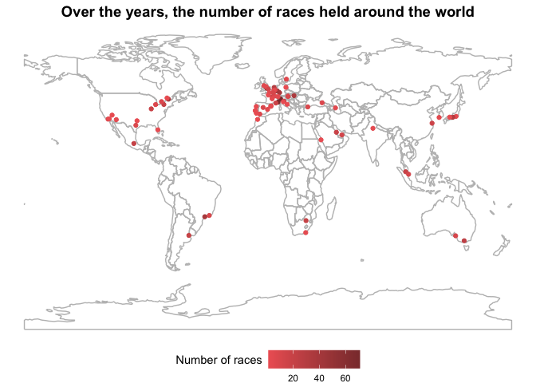

```r
# Download a world map shapefile
download.file(
  'https://stacks.stanford.edu/file/druid:ps917hm2349/data.zip',
  'World_map.zip')
unzip('World_map.zip')
#ogrInfo('.')
adm0 <- readOGR('.', 'ne_110m_admin_0_map_units')
#str(adm0)
adm0 <- fortify(adm0)
#str(adm0)

# check how many times each circuit appeared throughout the years from 1950-2021
df_1 <- as.data.table(races)
df_1 <- df_1[, .(count = .N), by = circuitId]
# merge this table with the circuits table
viz_1 <- merge(circuits, df_1)

# Create visualization
ggplot() +
  geom_path(data = adm0, aes(x = long, y = lat, group = group), color = 'gray') +
  geom_point(data = viz_1,aes(lng, lat, color = count)) +
  scale_color_gradient(low = 'indianred2', high = 'indianred4', name = 'Number of races') +
  theme_void() +
  ggtitle('Over the years, the number of races held around the world') +
  theme(legend.position = 'bottom',
        legend.justification = 'bottom',
        legend.box.just = 'bottom',
        legend.direction = 'horizontal',
        legend.title = element_text(vjust = 0.8),
        plot.title = element_text(size = 14, hjust = 0.5, face = 'bold'))
```

## Visualization 2

The appeal of the competition for me is that, on the one hand, while we are talking about a complex team sport, we also see easily measurable individual performances in the races. For example, Lewis Hamilton, without Mercedes, would probably not be considered one of the most talented drivers ever, yet the fact that he is not only one of the drivers with the most races, but also the one with the highest win rate (35.4%) is indisputable. The graph also shows since the beginning of Formula 1 (there have been a lot of drivers throughout the years, to be exact 853), there is already a huge gap in the number of races won between the top 10 most successful drivers. This is likely to be due to the fact that over the years, as interest has grown and the sport has developed structurally, more and more races have been organised in one year.

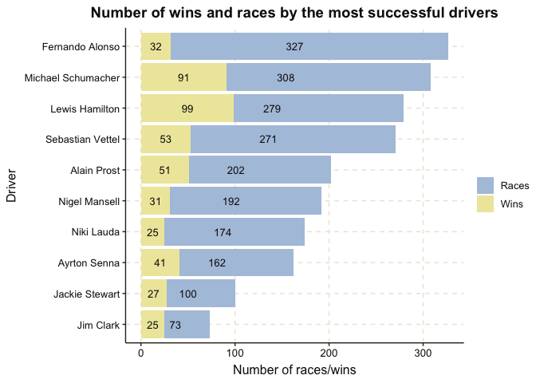

```r
# Merge tables
df_2 <- merge(results, races, by = 'raceId')
df_2 <- merge(df_2, drivers, by = 'driverId')

viz2 <- df_2[positionOrder == 1, .(wins = sum(positionOrder)), by = .(driverId, driver_name)][order(-wins)][1:10]
viz2_2 <- df_2[, .(races = .N), by = .(driverId)][order(driverId)]

viz2 <- merge(viz2, viz2_2, by = 'driverId')

ggthemr('fresh', type = 'outer')

# Create visualization
ggplot(viz2, aes(x = reorder(driver_name, races))) +
  geom_col(aes(y = races, fill = "Races")) +
  geom_text(aes(y = races/2, label = races), hjust = 0.5, vjust = 0.5, size = 3.5) +
  geom_col(aes(y = wins, fill = "Wins")) +
  geom_text(aes(y = wins/2, label = wins), hjust = 0.5, vjust = 0.5, size = 3.5) +
  scale_fill_manual(name = "", labels = c('Races', 'Wins'), values = c("lightsteelblue", "palegoldenrod")) +
  coord_flip() +
  xlab("Driver") +
  ylab("Number of races/wins") +
  ggtitle("Number of wins and races by the most successful drivers") +
  theme(plot.title = element_text(size = 14, hjust = 0.5, face = 'bold'),
        axis.text.x = element_text(hjust = 0.5, size = 10),
        axis.title = element_text(size = 12))
```

## Visualization 3

The beauty of Formula 1 is that winning a race is not the end of the competition, because drivers have to keep doing well throughout the season. In my next graph you can see the intense rivalry between Fernando Alonso and rookie teammate Lewis Hamilton and Ferrari’s driver Kimi Raikonnen in 2007. With two races to go Hamilton was on the doorstep of winning the championship, but an unexpected crash at the Chinese Grand Prix - where he slid off into the gravel by the pit entry lane - kept the championship alive. In the Brazilian final he suffered another misfortune when a gearbox problem dropped him to the back of the grid. Raikkonen needed to win and hope that Alonso finished no higher than third, Hamilton could only recover to seventh place; two positions short of what he needed to win the title. Although during the season it seemed that Raikonnen was the least likely to win the championship, he ended up being the champion.

[figure not shown]

```r
# Merge tables
df_3 <- merge(races, results, by = 'raceId')
df_3 <- merge(drivers, df_3, by = 'driverId')
df_3 <- merge(circuits, df_3, by = 'circuitId')

viz3 <- df_3 %>%
  filter(race_year == 2007, driver_name %in% c('Lewis Hamilton','Fernando Alonso', 'Kimi Räikkönen')) %>%
  group_by(driverId) %>%
  arrange(raceId) %>%
  mutate(cumulative_points = cumsum(points))

# Create visualization
f <- ggplot(data = viz3, aes(x = raceId, y = cumulative_points, color = as.factor(driverId))) +
  geom_line(size = 1.5, alpha = 0.8) +
  geom_point(alpha = 0.8) +
  scale_x_continuous(breaks = seq(36,52, by = 1),labels = unique(viz3$circuit_country)) +
  scale_y_continuous(breaks = seq(0,110, by = 10)) +
  scale_color_manual(name = "Drivers", labels = c("Lewis Hamilton", "Fernando Alonso", "Kimi Räikkönen"),
                     values = c("grey30", "darkorange2", "red4")) +
  ggtitle("The fight for the World Championship in 2007") +
  ylab('Points earned') +
  xlab('Locations') +
  theme(axis.text.x = element_text(angle = 50, vjust= 1, hjust= 0.8),
        legend.position = 'top',
        legend.title = element_text(vjust = 0.6),
        plot.title = element_text(size = 14, hjust = 0.5, face = 'bold')) +
  transition_reveal(raceId)
# Animate this graph
animate(f, end_pause = 40,fps = 5)
```

## Visualization 4

Formula 1 is an unbalanced sport in terms of team budgets. Success is largely determined by liquid funds, which the 2010 regulations sought to balance by influencing the budget available for a season. In my next graph, I have plotted the distribution of constructors’ points earned over the subsequent 8 years (between the teams who were present from 2010 to 2018), showing that there has been a redistribution among teams. After the regulations while Ferrari, Red Bull mostly maintained the amount of points received, McLaren dwindled over the years and Mercedes had a breakout success. Of course, these results cannot be linked to the amount of money spent, but they do show how much the strengths of the sport’s participants vary from year to year.

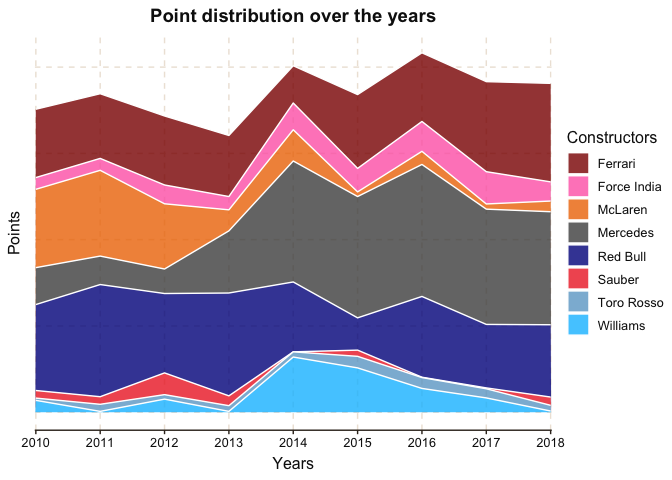

```r
# Merge tables
df_4 <- merge(constructors, constructor_results, by = 'constructorId')
df_4 <- merge(df_4, races, by = 'raceId')

# Create data frame for the visualization
viz4 <- df_4 %>%
  filter(race_year %in% c(2010,2011,2012,2013,2014,2015,2016,2017,2018)) %>%
  filter(constructor_name %in% c('Red Bull', 'McLaren', 'Ferrari','Force India','Mercedes','Williams','Toro Rosso','Sauber')) %>%
  group_by(constructor_name, race_year) %>%
  summarize(sum = sum(points))

# Create visualization
ggplot(data = viz4, aes(x=race_year, y=sum, fill=constructor_name)) +
  geom_area(alpha = 0.8,size=.5, colour="white") +
  scale_x_continuous(breaks = seq(2010,2018, by = 1), expand = c(0.001,0.001)) +
  scale_fill_manual(name = "Constructors",
                     labels = c('Ferrari','Force India','McLaren','Mercedes','Red Bull','Sauber','Toro Rosso','Williams'),
                     values = c('red4','hotpink',"darkorange2","grey30",'blue4',"firebrick2",'skyblue3','deepskyblue')) +
  ggtitle("Point distribution over the years") +
  xlab('Years') +
  ylab('Points') +
  theme(axis.line.y = element_blank(),
        axis.text.y = element_blank(),
        axis.ticks.y = element_blank(),
        plot.title = element_text(size = 14, hjust = 0.5, face = 'bold'))
```

## Visualization 5

But it’s not just drivers and teams that can shape Formula 1. Constant technical innovation is an essential element of the sport. Many people are not familiar with the construction of cars, so I wanted to illustrate the technical development with my last diagram in a way that would not require such knowledge. To do this, I compared the fastest laps in seconds for each Grand Prix, from 2010 to 2018. The dots represent the fastest lap times for each Grand Prix for a given year. The line shows the general trend over the years, from which we can see that the average did not improve much until 2015, and then we can see that the fastest lap times on average decrease until 2018.

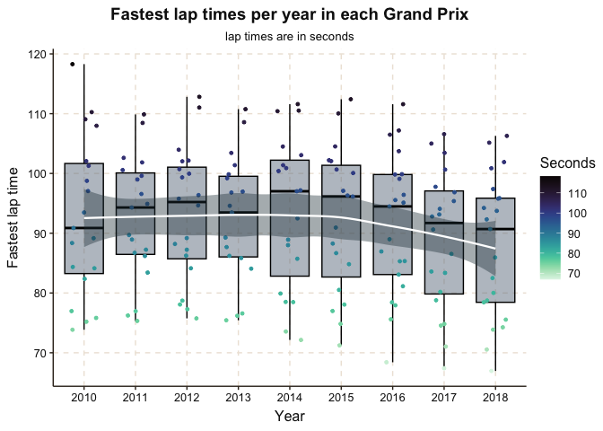

```r
# Merge tables
df_5 <- merge(results, races, by = 'raceId')
df_5 <- merge(df_5, circuits, by = 'circuitId')
df_5$fastestLapSpeed <- as.numeric(df_5$fastestLapSpeed)

# Create a function that converts Fastest Lap times to seconds
toSeconds <- function(x){
  if (!is.character(x)) stop("x must be a character string of the form H:M:S")
  if (length(x)<=0)return(x)

  unlist(
    lapply(x,
           function(i){
             i <- as.numeric(strsplit(i,':',fixed=TRUE)[[1]])
             if (length(i) == 3)
               i[1]*3600 + i[2]*60 + i[3]
             else if (length(i) == 2)
               i[1]*60 + i[2]
             else if (length(i) == 1)
               i[1]
           }
    )
  )
}

df_5$fastestLapTime <- toSeconds(df_5$fastestLapTime)


# Create data frame for the visualization
df_5 <- df_5 %>%
  select(race_year, race_name, fastestLapTime) %>%
  filter(race_year > 2009 & race_year < 2019) %>%
  group_by(race_name,race_year) %>%
  summarize(FastestLapTime = min(fastestLapTime,na.rm=T))

# Create visualization
ggplot(data = df_5,aes(x=as.factor(race_year),y= FastestLapTime,color=FastestLapTime)) +
  geom_boxplot(alpha= 0.5, color = 'black', fill = 'slategrey') +
  geom_jitter(size=1, width = 0.25) +
  geom_smooth(method='loess',aes(group=1),color='white',size=0.8, lty = 1) +
  scale_color_viridis(name = "Seconds", option = "G", guide = "colorbar", direction = -1) +
  labs(title='Fastest lap times per year in each Grand Prix',
       subtitle = 'lap times are in seconds') +
  ylab('Fastest lap time') +
  xlab('Year') +
  theme(plot.title = element_text(size = 14, hjust = 0.5, face = 'bold'),
        plot.subtitle = element_text(size = 10, hjust = 0.5))
```

## Conclusion

In my project, I presented the trends of Formula 1 in recent years and looked for the answer to why the sport is likeable. In terms of trends, I found that the sport is European-centric, sometimes dominated by a single driver year after year. In contrast, the distribution of points for teams varies over a 10-year period. To say that this is due to the talent of the drivers would require further question-specific studies. On the technical development side, I looked at a short period of time, but I could already see that the cars were performing better on average at the end of the period.

In terms of likeability the graphs showed, Formula 1 is extremely versatile: it is both a team and an individual sport, it is both a race and a season, and it can be both local and international.